# Fit a line with a robust loss

A least-squares problem separates the residual function from the choice of loss. This makes it easy to compare a quadratic loss with a robust alternative. We fit a line to a small synthetic data set containing three positive outliers. Euclidean space is a manifold too, so the same problem and solver interface applies without a geometric constraint.

## Generate observations and register the data

```r
set.seed(51)
x <- seq(-2, 2, length.out = 41)
y <- 1 + 1.5 * x + rnorm(length(x), sd = 0.15)
outliers <- c(31, 35, 39)
y[outliers] <- y[outliers] + 3

design <- cbind(intercept = 1, slope = x)
registered <- list(
  X = torch_tensor(design, dtype = torch_float64(), device = "cpu"),
  y = torch_tensor(y, dtype = torch_float64(), device = "cpu")
)
```

The point has two coordinates: the intercept and the slope. The residual callback returns one value for each observation, leaving the constructor to apply the chosen loss.

```r
coefficients <- manifold.euclidean(2)
make_problem <- function(loss) {
  riem.problem.leastsquares(
    coefficients,
    residual = function(beta, data) data$X$matmul(beta) - data$y,
    data = registered,
    loss = loss,
    loss_scale = 0.25
  )
}
```

With `loss = "linear"`, the objective is one half of the sum of squared residuals. With `loss = "huber"`, each residual has a quadratic loss up to an absolute value of `loss_scale`, and a linear loss beyond it. The threshold is in the units of the response; the value `0.25` is a choice for this simulated example, not an automatically estimated noise scale.

## Solve both problems

```r
losses <- c("linear", "huber")
fits <- setNames(lapply(losses, function(loss) {
  riem.optimize(
    make_problem(loss),
    torch_zeros(2, dtype = torch_float64(), device = "cpu"),
    method = "levenberg_marquardt",
    control = list(max_iterations = 100, gradient_tolerance = 1e-7),
    device = "cpu"
  )
}), losses)

estimates <- t(vapply(fits, function(fit) as.numeric(fit$point), numeric(2)))
colnames(estimates) <- c("Intercept", "Slope")
round(rbind(Generating_line = c(1, 1.5), estimates), 4)
```

```
#>                 Intercept  Slope
#> Generating_line    1.0000 1.5000
#> linear             1.2185 1.7354
#> huber              1.0083 1.5276
```

Levenberg–Marquardt uses a positive-semidefinite Gauss–Newton approximation. For robust losses it reweights individual residuals; that approximation is not the full Hessian of the robust objective. Automatic differentiation supplies the residual derivatives here.

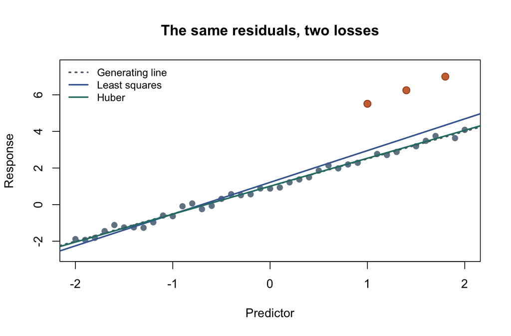

Huber loss reduces the effect of the three added outliers in this example.

## Verify against independent R calculations

For ordinary least squares, `lm.fit()` gives a direct reference. For Huber loss, write the scalar objective in base R and minimize it with `optim()`. The latter is a numerical cross-check rather than a closed-form solution.

```r
least_squares_reference <- lm.fit(design, y)$coefficients
huber_objective <- function(beta) {
  residual <- drop(design %*% beta) - y
  threshold <- 0.25
  sum(ifelse(abs(residual) <= threshold,
             residual^2 / 2,
             threshold * (abs(residual) - threshold / 2)))
}
huber_reference <- optim(c(0, 0), huber_objective, method = "BFGS",
                         control = list(reltol = 1e-12))

comparison <- data.frame(
  loss = losses,
  maximum_coefficient_error = c(
    max(abs(estimates["linear", ] - least_squares_reference)),
    max(abs(estimates["huber", ] - huber_reference$par))
  ),
  gradient_norm = vapply(fits, function(fit) fit$gradient_norm, numeric(1)),
  termination = vapply(fits, function(fit) fit$termination, character(1))
)
comparison
```

```
#>          loss maximum_coefficient_error gradient_norm        termination
#> linear linear              2.209122e-12  1.119662e-10 converged_gradient
#> huber   huber              1.308997e-09  6.211976e-08 converged_gradient
```

```r
stopifnot(huber_reference$convergence == 0,
          all(comparison$maximum_coefficient_error < 1e-5))
```

The two loss functions have different scales and meanings, so their raw objective values should not be used to rank the fits. Compare the coefficients, the residuals, and performance on data appropriate to your application.

`riem.problem.leastsquares()` also supports `"soft_l1"` and `"cauchy"` losses. Nonquadratic losses support diagonal residual weights. For automatic device selection, replace the explicit CPU override in the solve with `device = "auto"`; registered data travel with the problem.

Continue with industrial stack-loss measurements for a public-data application, or add explicit modeling assumptions in the constrained tree-volume example.